# Advertisment IP

Bradley Agwa

2022-03-26

###RESEARCH QUESTION

A Kenyan entrepreneur has created an online cryptography course and would want to advertise it on her blog. She currently targets audiences originating from various countries. In the past, she ran ads to advertise a related course on the same blog and collected data in the process. She would now like to employ your services as a Data Science Consultant to help her identify which individuals are most likely to click on her ads.

###Metrics Of Success

Perform Univariate and bivariate analysis and give insights based on the findings.

###Context In the recent past there has been an increase in the number of online click ads. This is because website owners and bloggers have realised that they could actually make money from the number of clicks on the ads they choose to advertise on their websites.

It is therefore necessary to create content that would be a target audience’s preferance in order to get them to their website(blog) and hopefully get them to click on the ads displayed.

###Experimental Design

1. Load the dataset
2. Explore the data i.e. find information and summaries of all the columns
3. Clean the data i.e. check and deal with missing data, duplicates and outliers in the dataset
4. Perform Univariate and Bivariate analysis.
5. Conclusions and Recommendations

## Importing packages

```r
#importing libraries
#data.table::update.dev.pkg() # install package data.table to work with data tables
#
#loading the library
library(data.table) # load package
#install.packages(c("Rcpp","tidyverse")) # install packages to work with data frame - extends into visualization
library(tidyverse)
```

## Importing dataset

```r
# Dataset Url = http://bit.ly/IPAdvertisingData
# Importing our dataset
# ---
#
advertising_dataset <- read.csv('http://bit.ly/IPAdvertisingData')
# Previewing the dataset
# ---
#having a look at the dataset
head(advertising_dataset, 6)
```

|  | Daily.Time.Spent.on.Site | Age | Area.Income | Daily.Internet.Usage | Ad.Topic.Line | City | Male | Country | Timestamp | Clicked.on.Ad |
| --- | --- | --- | --- | --- | --- | --- | --- | --- | --- | --- |
| 1 | 68.95 | 35 | 61833.90 | 256.09 | Cloned 5thgeneration orchestration | Wrightburgh | 0 | Tunisia | 2016-03-27 00:53:11 | 0 |
| 2 | 80.23 | 31 | 68441.85 | 193.77 | Monitored national standardization | West Jodi | 1 | Nauru | 2016-04-04 01:39:02 | 0 |
| 3 | 69.47 | 26 | 59785.94 | 236.50 | Organic bottom-line service-desk | Davidton | 0 | San Marino | 2016-03-13 20:35:42 | 0 |
| 4 | 74.15 | 29 | 54806.18 | 245.89 | Triple-buffered reciprocal time-frame | West Terrifurt | 1 | Italy | 2016-01-10 02:31:19 | 0 |
| 5 | 68.37 | 35 | 73889.99 | 225.58 | Robust logistical utilization | South Manuel | 0 | Iceland | 2016-06-03 03:36:18 | 0 |
| 6 | 59.99 | 23 | 59761.56 | 226.74 | Sharable client-driven software | Jamieberg | 1 | Norway | 2016-05-19 14:30:17 | 0 |

observation: the dateset has 10 columns.

### Previewing the dataset

```r
#viewing the dataset
#
View(advertising_dataset)
```

### checking the colunms summary

```r
# checking the content/summary statistics of each column.
str(advertising_dataset)
```

```
## 'data.frame':    1000 obs. of  10 variables:
##  $ Daily.Time.Spent.on.Site: num  69 80.2 69.5 74.2 68.4 ...
##  $ Age                     : int  35 31 26 29 35 23 33 48 30 20 ...
##  $ Area.Income             : num  61834 68442 59786 54806 73890 ...
##  $ Daily.Internet.Usage    : num  256 194 236 246 226 ...
##  $ Ad.Topic.Line           : chr  "Cloned 5thgeneration orchestration" "Monitored national standardization" "Organic bottom-line service-desk" "Triple-buffered reciprocal time-frame" ...
##  $ City                    : chr  "Wrightburgh" "West Jodi" "Davidton" "West Terrifurt" ...
##  $ Male                    : int  0 1 0 1 0 1 0 1 1 1 ...
##  $ Country                 : chr  "Tunisia" "Nauru" "San Marino" "Italy" ...
##  $ Timestamp               : chr  "2016-03-27 00:53:11" "2016-04-04 01:39:02" "2016-03-13 20:35:42" "2016-01-10 02:31:19" ...
##  $ Clicked.on.Ad           : int  0 0 0 0 0 0 0 1 0 0 ...
```

observation: the columns comprises of numerical, integer, and character data types.

### checking the dataset dimension.

```r
# dimension
dim(advertising_dataset)
```

```
## [1] 1000   10
```

### checking our dataset class

```r
class(advertising_dataset)
```

```
## [1] "data.frame"
```

### converting the data into a tibble for easy manupulation

```r
#For ease in analysis,we convert the data into a tibble
my_dataset<-as.tibble(advertising_dataset)
my_dataset
```

| Daily.Time.Spent.on.Site | Age | Area.Income | Daily.Internet.Usage | Ad.Topic.Line | City | Male | Country | Timestamp | Clicked.on.Ad |
| --- | --- | --- | --- | --- | --- | --- | --- | --- | --- |
| 68.95 | 35 | 61833.90 | 256.09 | Cloned 5thgeneration orchestration | Wrightburgh | 0 | Tunisia | 2016-03-27 00:53:11 | 0 |
| 80.23 | 31 | 68441.85 | 193.77 | Monitored national standardization | West Jodi | 1 | Nauru | 2016-04-04 01:39:02 | 0 |
| 69.47 | 26 | 59785.94 | 236.50 | Organic bottom-line service-desk | Davidton | 0 | San Marino | 2016-03-13 20:35:42 | 0 |
| 74.15 | 29 | 54806.18 | 245.89 | Triple-buffered reciprocal time-frame | West Terrifurt | 1 | Italy | 2016-01-10 02:31:19 | 0 |
| 68.37 | 35 | 73889.99 | 225.58 | Robust logistical utilization | South Manuel | 0 | Iceland | 2016-06-03 03:36:18 | 0 |
| 59.99 | 23 | 59761.56 | 226.74 | Sharable client-driven software | Jamieberg | 1 | Norway | 2016-05-19 14:30:17 | 0 |
| 88.91 | 33 | 53852.85 | 208.36 | Enhanced dedicated support | Brandonstad | 0 | Myanmar | 2016-01-28 20:59:32 | 0 |
| 66.00 | 48 | 24593.33 | 131.76 | Reactive local challenge | Port Jefferybury | 1 | Australia | 2016-03-07 01:40:15 | 1 |
| 74.53 | 30 | 68862.00 | 221.51 | Configurable coherent function | West Colin | 1 | Grenada | 2016-04-18 09:33:42 | 0 |
| 69.88 | 20 | 55642.32 | 183.82 | Mandatory homogeneous architecture | Ramirezton | 1 | Ghana | 2016-07-11 01:42:51 | 0 |

[output cut: 990 more lines]

Converting to makes manipulation easier.

### dataset summary

```r
summary(my_dataset)
```

```
##  Daily.Time.Spent.on.Site      Age         Area.Income    Daily.Internet.Usage
##  Min.   :32.60            Min.   :19.00   Min.   :13996   Min.   :104.8
##  1st Qu.:51.36            1st Qu.:29.00   1st Qu.:47032   1st Qu.:138.8
##  Median :68.22            Median :35.00   Median :57012   Median :183.1
##  Mean   :65.00            Mean   :36.01   Mean   :55000   Mean   :180.0
##  3rd Qu.:78.55            3rd Qu.:42.00   3rd Qu.:65471   3rd Qu.:218.8
##  Max.   :91.43            Max.   :61.00   Max.   :79485   Max.   :270.0
##  Ad.Topic.Line          City                Male         Country
##  Length:1000        Length:1000        Min.   :0.000   Length:1000
##  Class :character   Class :character   1st Qu.:0.000   Class :character
##  Mode  :character   Mode  :character   Median :0.000   Mode  :character
##                                        Mean   :0.481
##                                        3rd Qu.:1.000
##                                        Max.   :1.000
##   Timestamp         Clicked.on.Ad
##  Length:1000        Min.   :0.0
##  Class :character   1st Qu.:0.0
##  Mode  :character   Median :0.5
##                     Mean   :0.5
##                     3rd Qu.:1.0
##                     Max.   :1.0
```

This to assist us in getting a better understanding of our dataset

## 3.0 Data cleaning

###3.0a missing values

```r
# Identify missing data in our entire dataset using is.na() function
#
is.na(my_dataset)
```

[output not shown]

[output cut: 1987 more lines]

There is no missing values as all the result returns False result

###3.0b Checking for missing values using the complete function

```r
# Using complete function
my_dataset[!complete.cases(my_dataset),]
```

| Daily.Time.Spent.on.Site | Age | Area.Income | Daily.Internet.Usage | Ad.Topic.Line | City | Male | Country | Timestamp | Clicked.on.Ad |
| --- | --- | --- | --- | --- | --- | --- | --- | --- | --- |

On confirmation, we got 0 row output, and all columns are complete hence no missing values.

###3.0c Finding out total missing values in each column

```r
#Rechecking the sum of missing values to ascertain the above finding
#
colSums(is.na(my_dataset))
```

```
## Daily.Time.Spent.on.Site                      Age              Area.Income
##                        0                        0                        0
##     Daily.Internet.Usage            Ad.Topic.Line                     City
##                        0                        0                        0
##                     Male                  Country                Timestamp
##                        0                        0                        0
##            Clicked.on.Ad
##                        0
```

### 3.1a Duplicated Data

```r
#Identifying Duplicated Data
#
duplicated_rows <- my_dataset[duplicated(my_dataset),]
duplicated_rows
```

| Daily.Time.Spent.on.Site | Age | Area.Income | Daily.Internet.Usage | Ad.Topic.Line | City | Male | Country | Timestamp | Clicked.on.Ad |
| --- | --- | --- | --- | --- | --- | --- | --- | --- | --- |

There is no duplicated rows

### 3.1b showing unique items

```r
# Showing these unique items
#
unique_items <- my_dataset[!duplicated(my_dataset), ]
unique_items
```

| Daily.Time.Spent.on.Site | Age | Area.Income | Daily.Internet.Usage | Ad.Topic.Line | City | Male | Country | Timestamp | Clicked.on.Ad |
| --- | --- | --- | --- | --- | --- | --- | --- | --- | --- |
| 68.95 | 35 | 61833.90 | 256.09 | Cloned 5thgeneration orchestration | Wrightburgh | 0 | Tunisia | 2016-03-27 00:53:11 | 0 |
| 80.23 | 31 | 68441.85 | 193.77 | Monitored national standardization | West Jodi | 1 | Nauru | 2016-04-04 01:39:02 | 0 |
| 69.47 | 26 | 59785.94 | 236.50 | Organic bottom-line service-desk | Davidton | 0 | San Marino | 2016-03-13 20:35:42 | 0 |
| 74.15 | 29 | 54806.18 | 245.89 | Triple-buffered reciprocal time-frame | West Terrifurt | 1 | Italy | 2016-01-10 02:31:19 | 0 |
| 68.37 | 35 | 73889.99 | 225.58 | Robust logistical utilization | South Manuel | 0 | Iceland | 2016-06-03 03:36:18 | 0 |
| 59.99 | 23 | 59761.56 | 226.74 | Sharable client-driven software | Jamieberg | 1 | Norway | 2016-05-19 14:30:17 | 0 |
| 88.91 | 33 | 53852.85 | 208.36 | Enhanced dedicated support | Brandonstad | 0 | Myanmar | 2016-01-28 20:59:32 | 0 |
| 66.00 | 48 | 24593.33 | 131.76 | Reactive local challenge | Port Jefferybury | 1 | Australia | 2016-03-07 01:40:15 | 1 |
| 74.53 | 30 | 68862.00 | 221.51 | Configurable coherent function | West Colin | 1 | Grenada | 2016-04-18 09:33:42 | 0 |
| 69.88 | 20 | 55642.32 | 183.82 | Mandatory homogeneous architecture | Ramirezton | 1 | Ghana | 2016-07-11 01:42:51 | 0 |

[output cut: 990 more lines]

###3.2 Outliers

### installing outlier package and library

```r
# Installing outlier package
#install.packages("outliers")
#
library(outliers)
```

###3.2a Identifying the numeric class in the data and evaluating if there are any outliers

```r
#Checking the data types of the columns
#
Numeric<- my_dataset %>% select_if(is.numeric)
Numeric
```

| Daily.Time.Spent.on.Site | Age | Area.Income | Daily.Internet.Usage | Male | Clicked.on.Ad |
| --- | --- | --- | --- | --- | --- |
| 68.95 | 35 | 61833.90 | 256.09 | 0 | 0 |
| 80.23 | 31 | 68441.85 | 193.77 | 1 | 0 |
| 69.47 | 26 | 59785.94 | 236.50 | 0 | 0 |
| 74.15 | 29 | 54806.18 | 245.89 | 1 | 0 |
| 68.37 | 35 | 73889.99 | 225.58 | 0 | 0 |
| 59.99 | 23 | 59761.56 | 226.74 | 1 | 0 |
| 88.91 | 33 | 53852.85 | 208.36 | 0 | 0 |
| 66.00 | 48 | 24593.33 | 131.76 | 1 | 1 |
| 74.53 | 30 | 68862.00 | 221.51 | 1 | 0 |
| 69.88 | 20 | 55642.32 | 183.82 | 1 | 0 |

[output cut: 990 more lines]

```r
# Checking the data types of the columns
Categorical=my_dataset %>% select_if(is.character)
Categorical
```

| Ad.Topic.Line | City | Country | Timestamp |
| --- | --- | --- | --- |
| Cloned 5thgeneration orchestration | Wrightburgh | Tunisia | 2016-03-27 00:53:11 |
| Monitored national standardization | West Jodi | Nauru | 2016-04-04 01:39:02 |
| Organic bottom-line service-desk | Davidton | San Marino | 2016-03-13 20:35:42 |
| Triple-buffered reciprocal time-frame | West Terrifurt | Italy | 2016-01-10 02:31:19 |
| Robust logistical utilization | South Manuel | Iceland | 2016-06-03 03:36:18 |
| Sharable client-driven software | Jamieberg | Norway | 2016-05-19 14:30:17 |
| Enhanced dedicated support | Brandonstad | Myanmar | 2016-01-28 20:59:32 |
| Reactive local challenge | Port Jefferybury | Australia | 2016-03-07 01:40:15 |
| Configurable coherent function | West Colin | Grenada | 2016-04-18 09:33:42 |
| Mandatory homogeneous architecture | Ramirezton | Ghana | 2016-07-11 01:42:51 |

[output cut: 990 more lines]

### 3.2b Checking for outliers

```r
# checking outliers in numerical colunms
#
outlier(Numeric)
```

```
## Daily.Time.Spent.on.Site                      Age              Area.Income
##                    32.60                    61.00                 13996.50
##     Daily.Internet.Usage                     Male            Clicked.on.Ad
##                   269.96                     1.00                     1.00
```

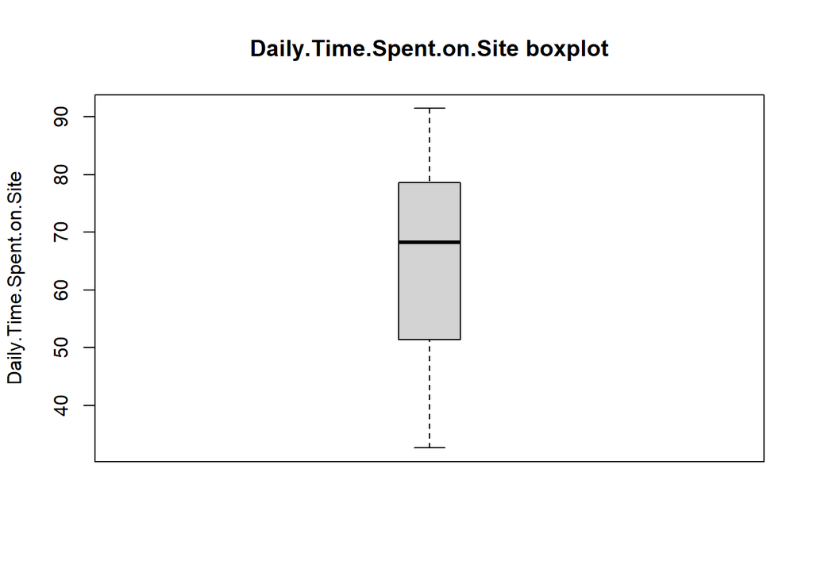

```r
# Checking the outliers in the 'Daily.Time.Spent.on.Site' Column.
#
boxplot(my_dataset$Daily.Time.Spent.on.Site, main= "Daily.Time.Spent.on.Site boxplot",ylab="Daily.Time.Spent.on.Site", boxwex=0.2)
```

There is no outlier in Daily.Time.Spent.on.Site colunm.

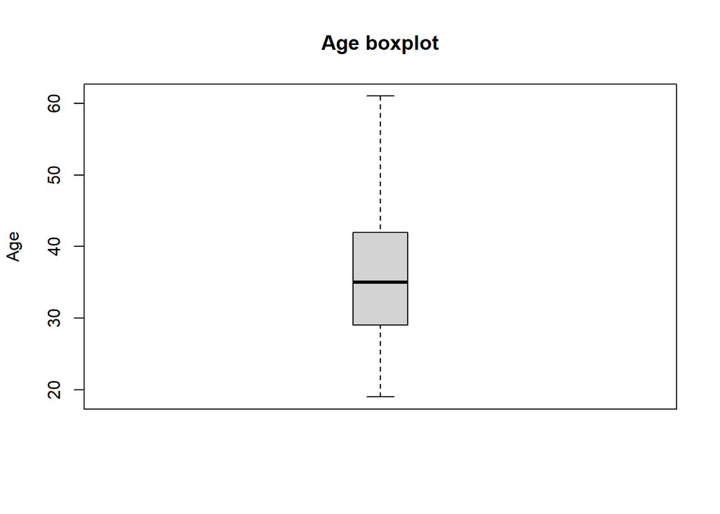

```r
# Checking the outliers in the 'Age' Column  using univariate approach
#
boxplot(my_dataset$Age, main="Age boxplot",ylab = "Age", boxwex=0.2)
```

There are no outliers in Age column

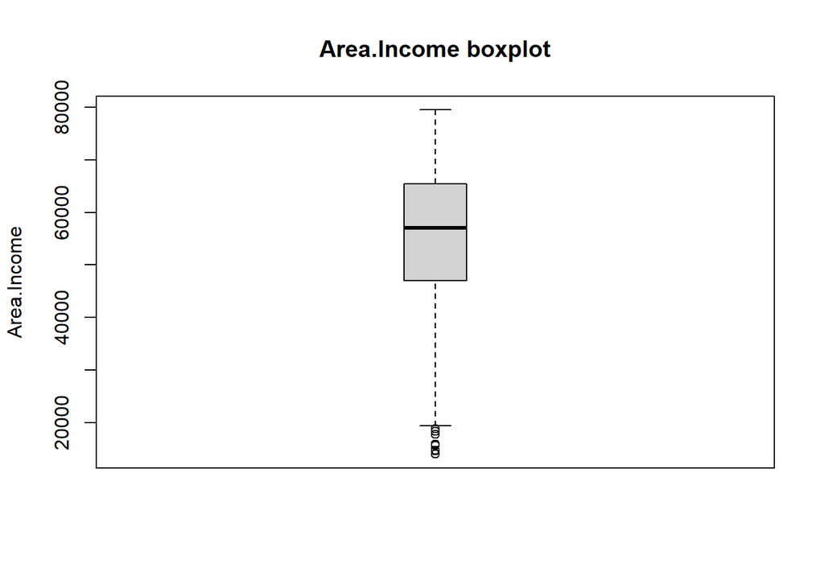

```r
# Checking the outliers in the 'Area.Income' Column  using univariate approach
#
boxplot(my_dataset$Area.Income, main="Area.Income boxplot",ylab = "Area.Income", boxwex=0.2)
```

### Installing the ggplot2 package and library

```r
#3.3ai installing ggplot2 package for visualization.
install.packages('ggplot2')
#
#installing ggplot2 library
#
library(ggplot2)
#
#note: the above  have been installed in the console section.
```

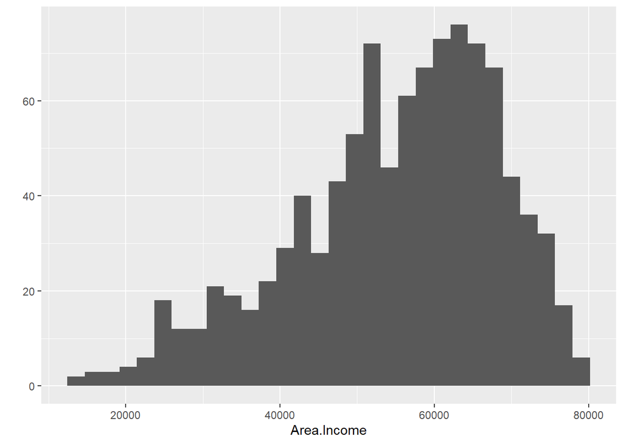

```r
# visualizing the colunm to check for outliers
ggplot2::qplot(data = my_dataset, x = Area.Income)
```

```r
#checking for outliers
outlier_value <-boxplot.stats(my_dataset$Area.Income)$out
outlier_value
```

```
## [1] 17709.98 18819.34 15598.29 15879.10 14548.06 13996.50 14775.50 18368.57
```

observation, there is outliers however this might be genuine thus we will not remove them since it is not extreme.

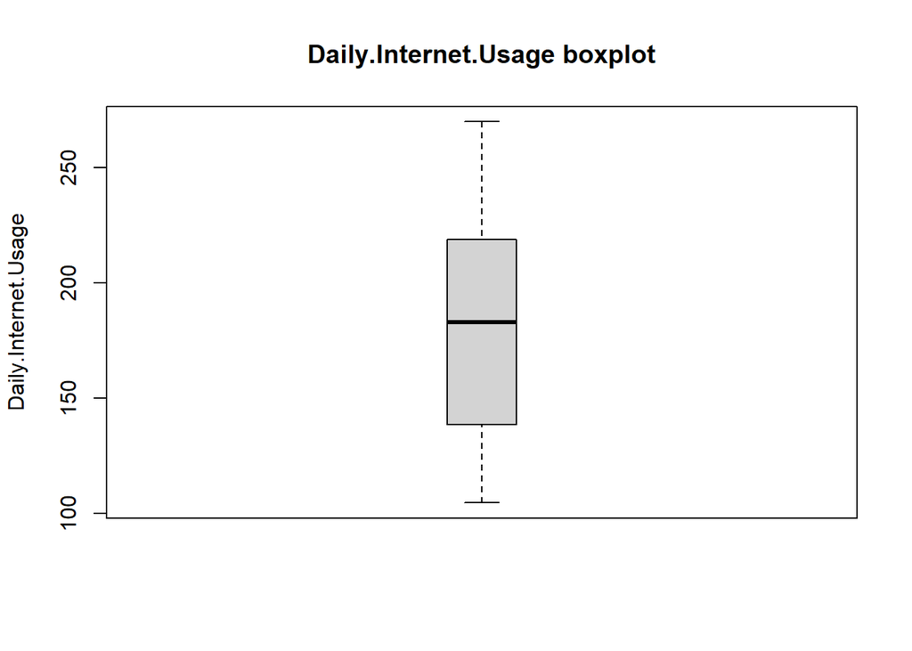

```r
# Checking the outliers in the 'Daily.Internet.Usage' Column  using univariate approach
#
boxplot(my_dataset$Daily.Internet.Usage, main="Daily.Internet.Usage boxplot",ylab = "Daily.Internet.Usage", boxwex=0.2)
```

observation, there is no outliers in Daily.Internet.Usage columns.

## Univariate Analysis for Numerical Data

```r
# Previewing the data types of the columns
#
Numeric
```

| Daily.Time.Spent.on.Site | Age | Area.Income | Daily.Internet.Usage | Male | Clicked.on.Ad |
| --- | --- | --- | --- | --- | --- |
| 68.95 | 35 | 61833.90 | 256.09 | 0 | 0 |
| 80.23 | 31 | 68441.85 | 193.77 | 1 | 0 |
| 69.47 | 26 | 59785.94 | 236.50 | 0 | 0 |
| 74.15 | 29 | 54806.18 | 245.89 | 1 | 0 |
| 68.37 | 35 | 73889.99 | 225.58 | 0 | 0 |
| 59.99 | 23 | 59761.56 | 226.74 | 1 | 0 |
| 88.91 | 33 | 53852.85 | 208.36 | 0 | 0 |
| 66.00 | 48 | 24593.33 | 131.76 | 1 | 1 |
| 74.53 | 30 | 68862.00 | 221.51 | 1 | 0 |
| 69.88 | 20 | 55642.32 | 183.82 | 1 | 0 |

[output cut: 990 more lines]

## checking for measure of central tedency

Computing mean, median,maximum, range, quantile, variance, std, & boxplots for each numeric column #

# central tedency for ‘Daily.Time.Spent.on.Site’ colunm

```r
#Finding the mean
DTS_m<-mean(my_dataset$Daily.Time.Spent.on.Site)
print(DTS_m)
```

```
## [1] 65.0002
```

```r
#Finding the median
DTS_m1<-median(my_dataset$Daily.Time.Spent.on.Site)
print(DTS_m1)
```

```
## [1] 68.215
```

```r
#Finding the maximum value in the Daily Time Spent on Site column
DTS_Max<-max(my_dataset$Daily.Time.Spent.on.Site)
print(DTS_Max)
```

```
## [1] 91.43
```

```r
#Finding the minimum value in the Daily Time Spent on Site column
DTS_Min<-min(my_dataset$Daily.Time.Spent.on.Site)
print(DTS_Min)
```

```
## [1] 32.6
```

```r
#Finding the range value of the Daily Time Spent on Site column
DTS_Range<-range(advertising_dataset$Daily.Time.Spent.on.Site)
print(DTS_Range)
```

```
## [1] 32.60 91.43
```

```r
#Finding the variance of the Daily Time Spent on Site column
DTS_Variance<-var(my_dataset$Daily.Time.Spent.on.Site)
print(DTS_Variance)
```

```
## [1] 251.3371
```

```r
#Finding the standard deviation of the Daily Time Spent on Site column
DTS_Sd<-sd(my_dataset$Daily.Time.Spent.on.Site)
print(DTS_Sd)
```

```
## [1] 15.85361
```

### creating mode() function.

```r
# We create the mode function that will perform our mode operation for us
getmode <- function(v) {
   uniqv <- unique(v)
   uniqv[which.max(tabulate(match(v, uniqv)))]
}
#
#finding the mode
DTS.Mode<-getmode(my_dataset$Daily.Time.Spent.on.Site)
DTS.Mode
```

```
## [1] 62.26
```

### 4.1d finding quantile for ‘Time.Spent.on.Site’ variable

```r
DTS_quantile <- quantile(my_dataset$Daily.Time.Spent.on.Site)
DTS_quantile
```

```
##      0%     25%     50%     75%    100%
## 32.6000 51.3600 68.2150 78.5475 91.4300
```

### 4.1e “Daily.Time.Spent.on.Site” variable histogram

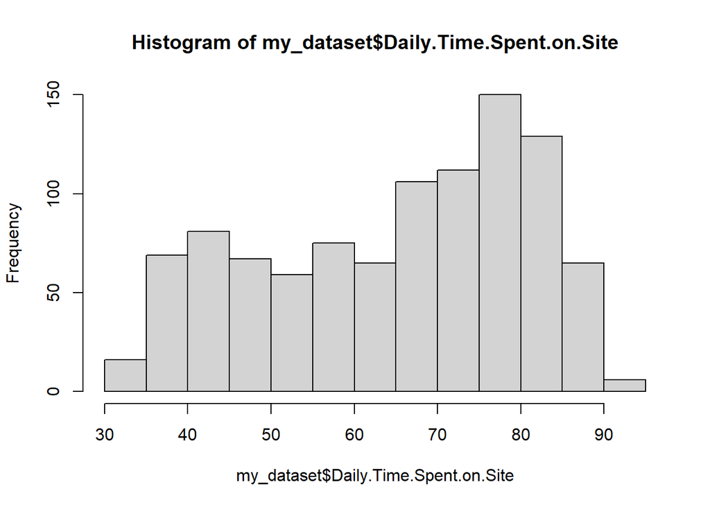

```r
#Checking the distribution of Daily Time Spent on Site
hist(my_dataset$Daily.Time.Spent.on.Site)
```

80 daily time spend on the side registered higher records.

### 4.1c central tedency for Age colunm

```r
#Finding the mean
Age_m<-mean(my_dataset$Age)
print(Age_m)
```

```
## [1] 36.009
```

```r
#Finding the median
Age_m1<-median(my_dataset$Age)
print(Age_m1)
```

```
## [1] 35
```

```r
#Finding the maximum value in the age column
Age_Max<-max(my_dataset$Age)
print(Age_Max)
```

```
## [1] 61
```

```r
#Finding the minimum value in the age column
Age_Min<-min(my_dataset$Age)
print(Age_Min)
```

```
## [1] 19
```

```r
#Finding the range value of the age column
Age_Range<-range(my_dataset$Age)
print(Age_Range)
```

```
## [1] 19 61
```

```r
#Finding the variance of the age column
Age_Variance<-var(my_dataset$Age)
print(Age_Variance)
```

```
## [1] 77.18611
```

```r
#Finding the standard deviation of the age column
Age_Sd<-sd(my_dataset$Age)
print(Age_Sd)
```

```
## [1] 8.785562
```

```r
#finding the mode## mode function was created in the console section to avoid several installation.
Age_Mode<-getmode(my_dataset$Age)
Age_Mode
```

```
## [1] 31
```

```r
#4.2d finding quantile for 'Age' variable
Age_Mode<-quantile(my_dataset$Age)
Age_Mode
```

```
##   0%  25%  50%  75% 100%
##   19   29   35   42   61
```

###4.2e “Age” variable histogram

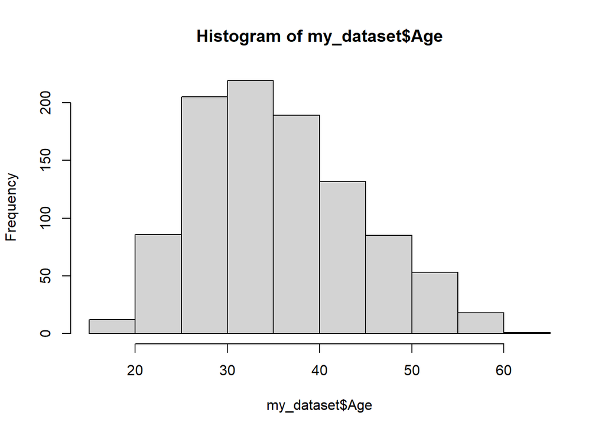

```r
#Checking the distribution of Age
hist(my_dataset$Age)
```

30 to 35 years registered high records.

## central tedency for Area.Income colunm

```r
#Finding the mean
AI_m<-mean(my_dataset$Area.Income)
print(AI_m)
```

```
## [1] 55000
```

```r
#
#Finding the median
AI_m1<-median(my_dataset$Area.Income)
print(AI_m1)
```

```
## [1] 57012.3
```

```r
#
#Finding the maximum value in the Area Income column
AI_Max<-max(my_dataset$Area.Income)
print(AI_Max)
```

```
## [1] 79484.8
```

```r
#
#Finding the minimum value in the Area Income column
AI_Min<-min(my_dataset$Area.Income)
print(AI_Min)
```

```
## [1] 13996.5
```

```r
#
#Finding the range value of the Area Income column
AI_Range<-range(my_dataset$Area.Income)
print(AI_Range)
```

```
## [1] 13996.5 79484.8
```

```r
#
#Finding the variance of the Area Income column
AI_Variance<-var(my_dataset$Area.Income)
print(AI_Variance)
```

```
## [1] 179952406
```

```r
#
#Finding the standard deviation of the  Area Income column
AI_Sd<-sd(my_dataset$Area.Income)
print(AI_Sd)
```

```
## [1] 13414.63
```

```r
#
#Finding the mode of the Area Income colunm
AI_Mode<-getmode(my_dataset$Area.Income)
print(AI_Mode)
```

```
## [1] 61833.9
```

```r
#
#finding the quantile the Area Income colunm
AI_quantile<- quantile(my_dataset$Area.Income)
print(AI_quantile)
```

```
##       0%      25%      50%      75%     100%
## 13996.50 47031.80 57012.30 65470.64 79484.80
```

## “Area Income” variable histogram

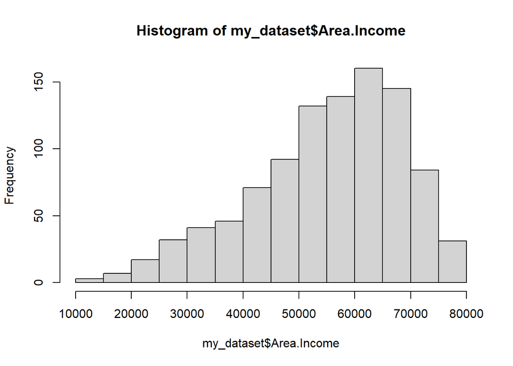

```r
# Checking the distribution of Area Income
hist(my_dataset$Area.Income)
```

Highest records were between 50000 and 70000 area income.

### central tedency for Daily.Internet.Usage colunm

```r
#Finding the mean
DIU_m<-mean(my_dataset$Daily.Internet.Usage)
print(DIU_m)
```

```
## [1] 180.0001
```

```r
#Finding the median
DIU_m1<-median(my_dataset$Daily.Internet.Usage)
print(DIU_m1)
```

```
## [1] 183.13
```

```r
#Finding the maximum value in the Daily Internet Usage column
DIU_Max<-max(my_dataset$Daily.Internet.Usage)
print(DIU_Max)
```

```
## [1] 269.96
```

```r
#Finding the minimum value in the Daily Internet Usage column
DIU_Min<-min(my_dataset$Daily.Internet.Usage)
print(DIU_Min)
```

```
## [1] 104.78
```

```r
#Finding the range value of the Daily Internet Usagecolumn
DIU_Range<-range(my_dataset$Daily.Internet.Usage)
print(DIU_Range)
```

```
## [1] 104.78 269.96
```

```r
#Finding the variance of the Daily Internet Usage column
DIU_Variance<-var(my_dataset$Daily.Internet.Usage)
print(DIU_Variance)
```

```
## [1] 1927.415
```

```r
#Finding the standard deviation Daily Internet Usage column
DIU_Sd<-sd(my_dataset$Daily.Internet.Usage)
print(DIU_Sd)
```

```
## [1] 43.90234
```

```r
#Finding the mode of the Daily internet usage colunm
DIU_Mode<-getmode(my_dataset$Daily.Internet.Usage)
print(DIU_Mode)
```

```
## [1] 167.22
```

```r
#
#finding the quantile the Daily internet usage colunm
DIU_quantile<- quantile(my_dataset$Daily.Internet.Usage)
print(DIU_quantile)
```

```
##       0%      25%      50%      75%     100%
## 104.7800 138.8300 183.1300 218.7925 269.9600
```

## Daily.Internet.Usage variable histogram

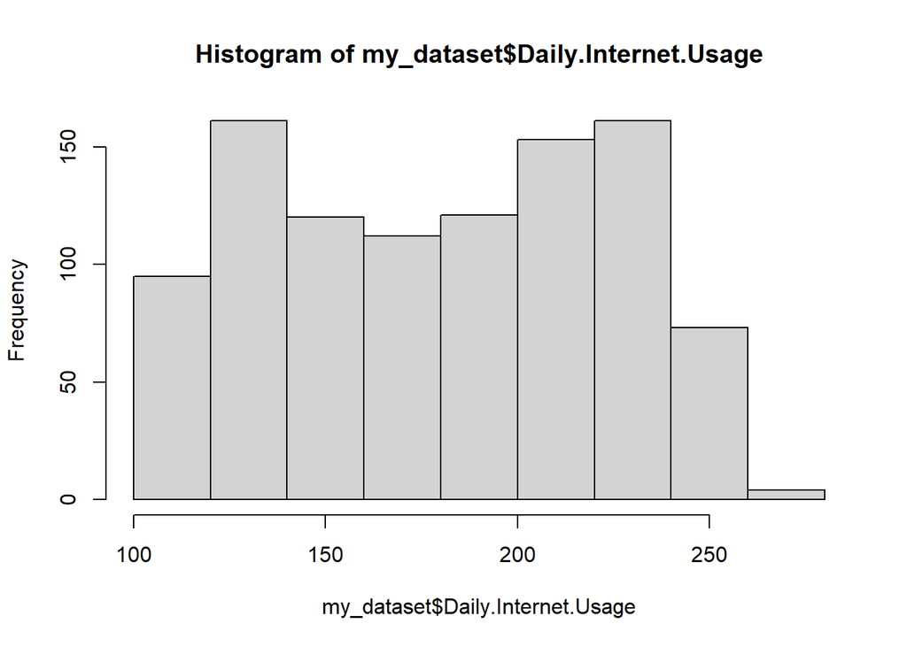

```r
# Checking the distribution of Daily internet Usage
hist(my_dataset$Daily.Internet.Usage)
```

Highest records were witnessed at 125mbs and 225mbs daily internet usage.

## Summary statistics of the numerical variables

```r
#Getting the summary statistics of the numeric variables.
summary(Numeric)
```

```
##  Daily.Time.Spent.on.Site      Age         Area.Income    Daily.Internet.Usage
##  Min.   :32.60            Min.   :19.00   Min.   :13996   Min.   :104.8
##  1st Qu.:51.36            1st Qu.:29.00   1st Qu.:47032   1st Qu.:138.8
##  Median :68.22            Median :35.00   Median :57012   Median :183.1
##  Mean   :65.00            Mean   :36.01   Mean   :55000   Mean   :180.0
##  3rd Qu.:78.55            3rd Qu.:42.00   3rd Qu.:65471   3rd Qu.:218.8
##  Max.   :91.43            Max.   :61.00   Max.   :79485   Max.   :270.0
##       Male       Clicked.on.Ad
##  Min.   :0.000   Min.   :0.0
##  1st Qu.:0.000   1st Qu.:0.0
##  Median :0.000   Median :0.5
##  Mean   :0.481   Mean   :0.5
##  3rd Qu.:1.000   3rd Qu.:1.0
##  Max.   :1.000   Max.   :1.0
```

## Univariate Analysis for categorical Variables

```r
#Checking the data types of the categorical columns
Categorical=my_dataset %>% select_if(is.character)
Categorical
```

| Ad.Topic.Line | City | Country | Timestamp |
| --- | --- | --- | --- |
| Cloned 5thgeneration orchestration | Wrightburgh | Tunisia | 2016-03-27 00:53:11 |
| Monitored national standardization | West Jodi | Nauru | 2016-04-04 01:39:02 |
| Organic bottom-line service-desk | Davidton | San Marino | 2016-03-13 20:35:42 |
| Triple-buffered reciprocal time-frame | West Terrifurt | Italy | 2016-01-10 02:31:19 |
| Robust logistical utilization | South Manuel | Iceland | 2016-06-03 03:36:18 |
| Sharable client-driven software | Jamieberg | Norway | 2016-05-19 14:30:17 |
| Enhanced dedicated support | Brandonstad | Myanmar | 2016-01-28 20:59:32 |
| Reactive local challenge | Port Jefferybury | Australia | 2016-03-07 01:40:15 |
| Configurable coherent function | West Colin | Grenada | 2016-04-18 09:33:42 |
| Mandatory homogeneous architecture | Ramirezton | Ghana | 2016-07-11 01:42:51 |

[output cut: 990 more lines]

## Male column frequencty barplot

```r
Gender <- my_dataset$Male
Gender_frequency<- table(Gender)
Gender_frequency
```

```
## Gender
##   0   1
## 519 481
```

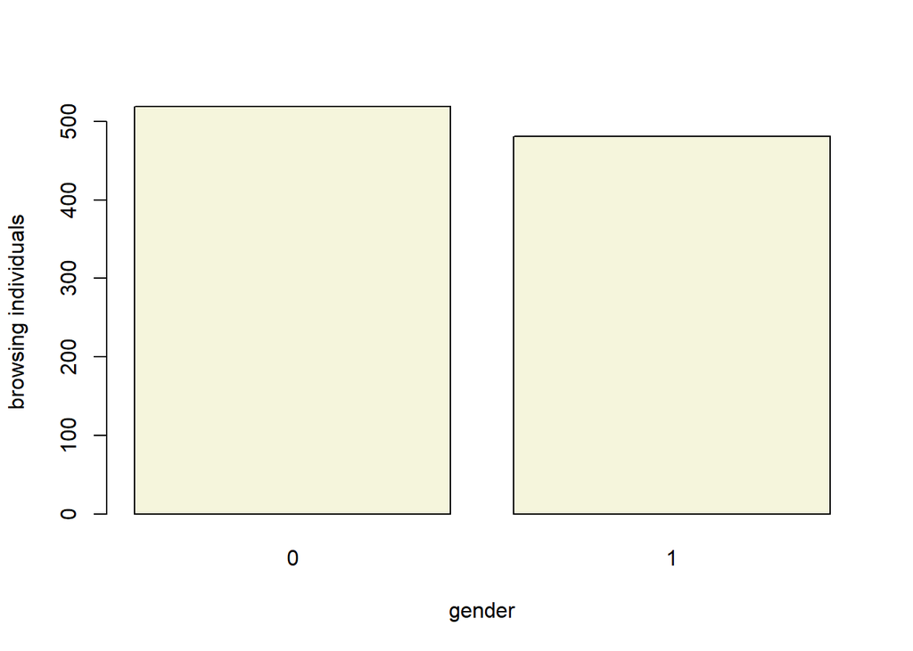

```r
barplot(Gender_frequency,xlab ="gender", ylab = "browsing individuals", col="beige")
```

From a sample of 1000 individuals,519 were female whereas 481 were male

## Clicked.on.Ad column frequencty barplot

```r
Clicked <- my_dataset$Clicked.on.Ad
Clicked_frequency<- table(Clicked)
Clicked_frequency
```

```
## Clicked
##   0   1
## 500 500
```

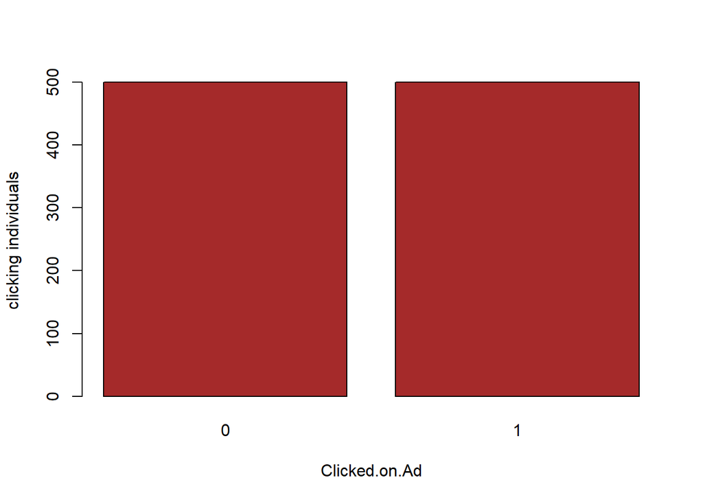

```r
barplot(Clicked_frequency,xlab ="Clicked.on.Ad", ylab = "clicking individuals", col="brown")
```

From 1000 individuals,500 people clicked on the advert whereas an equal number did not click the ad.

## Country column frequencty barplot

```r
Country <- my_dataset$Country
Country_frequency<- table(Country)
Country_frequency
```

```
## Country
##                                         Afghanistan
##                                                   8
##                                             Albania
##                                                   7
##                                             Algeria
##                                                   6
##                                      American Samoa
##                                                   5
##                                             Andorra
##                                                   2
##                                              Angola
##                                                   4
##                                            Anguilla
##                                                   6
##        Antarctica (the territory South of 60 deg S)
##                                                   3
##                                 Antigua and Barbuda
##                                                   5
##                                           Argentina
##                                                   2
##                                             Armenia
##                                                   3
##                                               Aruba
##                                                   1
##                                           Australia
##                                                   8
##                                             Austria
##                                                   5
##                                          Azerbaijan
##                                                   3
##                                             Bahamas
##                                                   7
##                                             Bahrain
##                                                   5
##                                          Bangladesh
##                                                   4
##                                            Barbados
##                                                   5
##                                             Belarus
```

[output cut: 420 more lines]

```
##                                                   6
##                                           Venezuela
##                                                   7
##                                             Vietnam
##                                                   3
##                                   Wallis and Futuna
##                                                   4
##                                      Western Sahara
##                                                   7
##                                               Yemen
##                                                   3
##                                              Zambia
##                                                   4
##                                            Zimbabwe
##                                                   6
```

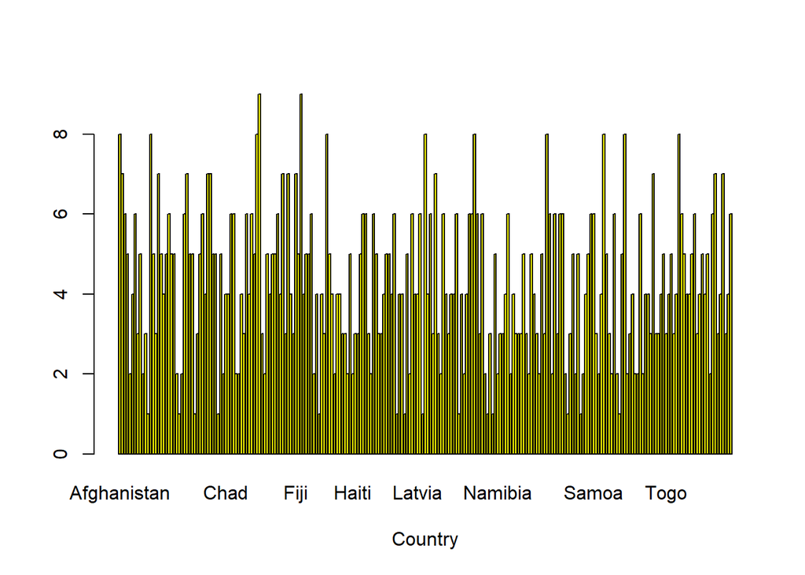

```r
barplot(Country_frequency,xlab ="Country", col="yellow")
```

```r
City <- my_dataset$City
City_frequency<- table(City)
City_frequency
```

```
## City
##               Adamsbury                Adamside               Adamsstad
##                       1                       1                       1
##                Alanview           Alexanderfurt           Alexanderview
##                       1                       1                       1
##           Alexandrafort              Alexisland              Aliciatown
##                       1                       1                       1
##            Alvaradoport             Alvarezland              Amandafort
##                       1                       1                       1
##             Amandahaven              Amandaland                 Amyfurt
##                       1                       1                       1
##                Amyhaven         Andersonchester            Andersonfurt
##                       1                       1                       1
##             Andersonton           Andrewborough             Andrewmouth
##                       1                       1                       1
##              Angelhaven             Anthonyfurt           Ashleychester
##                       1                       1                       1
##             Ashleymouth           Austinborough              Austinland
##                       1                       1                       1
##              Bakerhaven             Barbershire                 Beckton
##                       1                       1                       1
##         Benjaminchester              Bernardton               Bethburgh
##                       2                       1                       1
##               Birdshire            Blairborough              Blairville
##                       1                       1                       1
##             Blevinstown               Bowenview               Boyerberg
##                       1                       1                       1
##          Bradleyborough            Bradleyburgh             Bradleyside
##                       1                       1                       1
##         Bradshawborough               Bradyfurt              Brandiland
##                       1                       1                       1
##             Brandonbury             Brandonstad             Brandymouth
##                       1                       1                       1
##             Brendaburgh           Brendachester              Brianabury
##                       1                       1                       1
##               Brianfurt               Brianland         Brittanyborough
##                       1                       1                       1
##               Brownbury               Brownport                Brownton
##                       1                       1                       1
##               Browntown               Brownview              Bruceburgh
```

[output cut: 592 more lines]

```
##                       1                       1                       1
##             Whitneyfort              Wilcoxport            Williammouth
##                       1                       1                       1
##             Williamport         Williamsborough            Williamsfort
##                       1                       1                       1
##           Williamsmouth            Williamsport            Williamsside
##                       1                       3                       1
##             Williamstad             Wilsonburgh             Wintersfort
##                       1                       1                       1
##                Wongland             Wrightburgh              Wrightview
##                       1                       2                       1
##                Yangside              Youngburgh               Youngfort
##                       1                       1                       1
##                   Yuton             Zacharystad              Zacharyton
##                       1                       1                       1
```

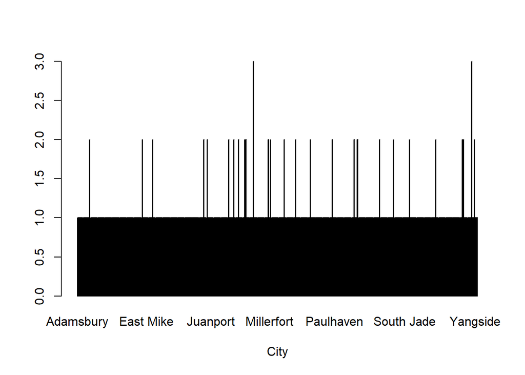

```r
barplot(City_frequency,xlab ="City", col="grey")
```

## Topic.Line column frequencty barplot

```r
Topic <- my_dataset$Ad.Topic.Line
Topic_frequency<- table(Topic)
Topic_frequency
```

```
## Topic
##                       Adaptive 24hour Graphic Interface
##                                                       1
##                          Adaptive asynchronous attitude
##                                                       1
##                  Adaptive context-sensitive application
##                                                       1
##                 Adaptive contextually-based methodology
##                                                       1
##                    Adaptive demand-driven knowledgebase
##                                                       1
##                             Adaptive uniform capability
##                                                       1
##                              Advanced 24/7 productivity
##                                                       1
##                       Advanced 5thgeneration capability
##                                                       1
##                        Advanced didactic conglomeration
##                                                       1
##                 Advanced disintermediate data-warehouse
##                                                       1
##                         Advanced exuding conglomeration
##                                                       1
##                           Advanced full-range migration
##                                                       1
##                             Advanced heuristic firmware
##                                                       1
##                               Advanced local task-force
##                                                       1
##                     Advanced modular Local Area Network
##                                                       1
##                          Advanced systemic productivity
##                                                       1
##                    Advanced web-enabled standardization
##                                                       1
##                         Ameliorated actuating workforce
##                                                       1
##             Ameliorated bandwidth-monitored contingency
##                                                       1
##                      Ameliorated client-driven forecast
```

[output cut: 1946 more lines]

```
##                                                       1
##                           Visionary analyzing structure
##                                                       1
##                         Visionary asymmetric encryption
##                                                       1
##                    Visionary client-driven installation
##                                                       1
##                 Visionary maximized process improvement
##                                                       1
##                  Visionary mission-critical application
##                                                       1
##                        Visionary multi-tasking alliance
##                                                       1
##                            Visionary reciprocal circuit
##                                                       1
```

## Bivariate and Multivariate Analysis

Covariance,correlation coefficient, and scatter plots

## Covariance between age and the daily time spent on site

```r
#Checking the covariance between age and the daily time spent on site
#
## Assigning the Age column to the variable Age
Age<-my_dataset$Age
#
#assigning Daily.Time.Spent.on.Site colunm to variable DTSS
DTSS<-my_dataset$Daily.Time.Spent.on.Site
#
#Using the cov() function to determine the covariance
cov(Age,DTSS)
```

```
## [1] -46.17415
```

he covariance of Age and Daily.Time.Spent.on.Site variable is about -46.175, indicating a negative linear relationship between the two variables

## Covariance between age and Daily.Internet.Usage

```r
#Checking the covariance between age and the daily time spent on site
#
## Assigning the Age column to the variable Age
Age<-my_dataset$Age
#
#assigning Daily.Internet.Usage colunm to variable DIU
DIU<-my_dataset$Daily.Internet.Usage
#
#Using the cov() function to determine the covariance
cov(Age,DIU)
```

```
## [1] -141.6348
```

The covariance of Age and Daily.Internet.Usage variable is about -141.635, indicating a negative linear relationship between the two variables

## Covariance between age and Area Income

```r
#Checking the covariance between age and the daily time spent on site
#
## Assigning the Age column to the variable Age
Age<-my_dataset$Age
#
#assigning  Area Income colunm to variable income
income<-my_dataset$Area.Income
#
#Using the cov() function to determine the covariance
cov(Age,income)
```

```
## [1] -21520.93
```

## covariance between Daily Time Spent on Site and the Daily Internet Usage

```r
#Using the cov() function to determine the covariance
cov(DTSS,DIU)
```

```
## [1] 360.9919
```

The higher the Daily Time Spent on Site the higher the Daily Internet Usage-Positive Covariance

## covariance between gender and Clicked.on.Ad

```r
#Using the cov() function to determine the covariance
cov(Gender,Clicked)
```

```
## [1] -0.00950951
```

## covariance between Clicked.on.Ad and age

```r
#Using the cov() function to determine the covariance
cov(Clicked,Age)
```

```
## [1] 2.164665
```

## covariance between Clicked.on.Ad and Daily.Time.Spent.on.Site

```r
#Using the cov() function to determine the covariance
cov(Clicked,DTSS)
```

```
## [1] -5.933143
```

## covariance between Clicked.on.Ad and Daily.Internet.Usage

```r
#Using the cov() function to determine the covariance
cov(Clicked,DIU)
```

```
## [1] -17.27409
```

## covariance between Clicked.on.Ad and Area income

```r
#Using the cov() function to determine the covariance
cov(Clicked,income)
```

```
## [1] -3195.989
```

##covariance for numerical colunms

```r
#Using the cov() function to determine the covariance
cov(Numeric)
```

```
##                          Daily.Time.Spent.on.Site           Age   Area.Income
## Daily.Time.Spent.on.Site              251.3370949 -4.617415e+01  6.613081e+04
## Age                                   -46.1741459  7.718611e+01 -2.152093e+04
## Area.Income                         66130.8109082 -2.152093e+04  1.799524e+08
## Daily.Internet.Usage                  360.9918827 -1.416348e+02  1.987625e+05
## Male                                   -0.1501864 -9.242142e-02  8.867509e+00
## Clicked.on.Ad                          -5.9331431  2.164665e+00 -3.195989e+03
##                          Daily.Internet.Usage        Male Clicked.on.Ad
## Daily.Time.Spent.on.Site         3.609919e+02 -0.15018639 -5.933143e+00
## Age                             -1.416348e+02 -0.09242142  2.164665e+00
## Area.Income                      1.987625e+05  8.86750903 -3.195989e+03
## Daily.Internet.Usage             1.927415e+03  0.61476667 -1.727409e+01
## Male                             6.147667e-01  0.24988889 -9.509510e-03
## Clicked.on.Ad                   -1.727409e+01 -0.00950951  2.502503e-01
```

The columns below have a positive covariance

1.Area Income and Daily Time Spent on Site

2.Age and Clicking on the Advert.

3.Area Income and Daily Internet Usage.

4.Area Income and Male

5.Daily Internet Usage and Daily Time Spent on Site

6.Male and Daily Internet Usage

7.Clicked on Advert and Age

The rest of the variables show negative covariance.

## correlation between age and Daily Time Spent on Site

```r
cor(Age,DTSS)
```

```
## [1] -0.3315133
```

## correlation between age and Daily Internet Usage

```r
cor(Age,DIU)
```

```
## [1] -0.3672086
```

## correlation between age and income

```r
cor(Age,income)
```

```
## [1] -0.182605
```

## correlation between age and Clicked on Advert

```r
cor(Age,Clicked)
```

```
## [1] 0.4925313
```

## correlation between Daily Time Spent on Site and Daily Internet Usage

```r
cor(DTSS,DIU)
```

```
## [1] 0.5186585
```

## correlation between Gender and Clicked on Advert

```r
cor(Gender,Clicked)
```

```
## [1] -0.03802747
```

## correlation between Gender and Daily Time Spent on Site

```r
cor(Gender,DTSS)
```

```
## [1] -0.01895085
```

## correlation between Gender and Daily internet usage

```r
cor(Gender,DIU)
```

```
## [1] 0.02801233
```

## correlation between Clicked on Advert and area income

```r
cor(Clicked,income)
```

```
## [1] -0.4762546
```

### correlation for numerical colunms

```r
#Using the cov() function to determine the covariance
cor(Numeric)
```

```
##                          Daily.Time.Spent.on.Site         Age  Area.Income
## Daily.Time.Spent.on.Site               1.00000000 -0.33151334  0.310954413
## Age                                   -0.33151334  1.00000000 -0.182604955
## Area.Income                            0.31095441 -0.18260496  1.000000000
## Daily.Internet.Usage                   0.51865848 -0.36720856  0.337495533
## Male                                  -0.01895085 -0.02104406  0.001322359
## Clicked.on.Ad                         -0.74811656  0.49253127 -0.476254628
##                          Daily.Internet.Usage         Male Clicked.on.Ad
## Daily.Time.Spent.on.Site           0.51865848 -0.018950855   -0.74811656
## Age                               -0.36720856 -0.021044064    0.49253127
## Area.Income                        0.33749553  0.001322359   -0.47625463
## Daily.Internet.Usage               1.00000000  0.028012326   -0.78653918
## Male                               0.02801233  1.000000000   -0.03802747
## Clicked.on.Ad                     -0.78653918 -0.038027466    1.00000000
```

There are positive Correlations between the following columns 1.Age and Clicking on the advert 2.Male and Daily Internet Usage 3.Male and Area Income 4.Daily Time Spent on Site and Daily Internet Usage. 5.Area Income and Daily Time Spent on Site 6.Area Income and Daily Internet Usage 7.Area Income and Male 8.Age and Clicking on the Advert.

## age and time spend on the site variable scatter plot

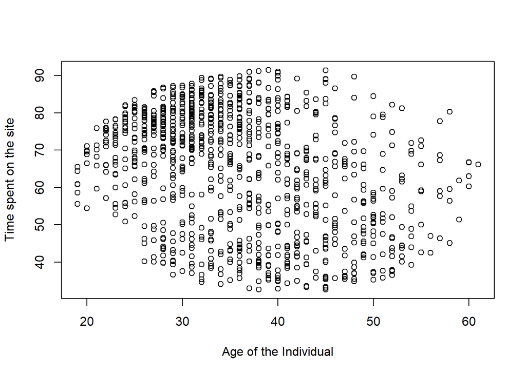

```r
#Using the plot() function to determine the relation
#
plot(Age, DTSS, xlab="Age of the Individual", ylab="Time spent on the site")
```

##age and Daily internate usage scatter plot

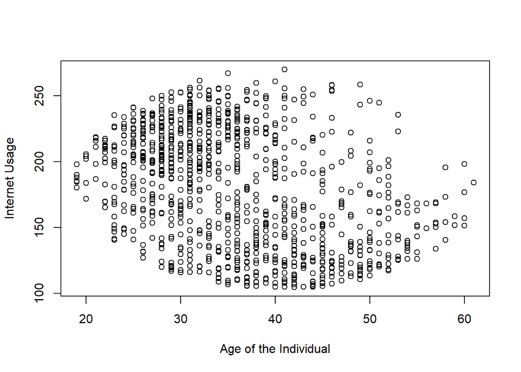

```r
#Using the plot() function to determine the relation
#
plot(Age, DIU, xlab="Age of the Individual", ylab="Internet Usage")
```

## age and area income variable scatter plot

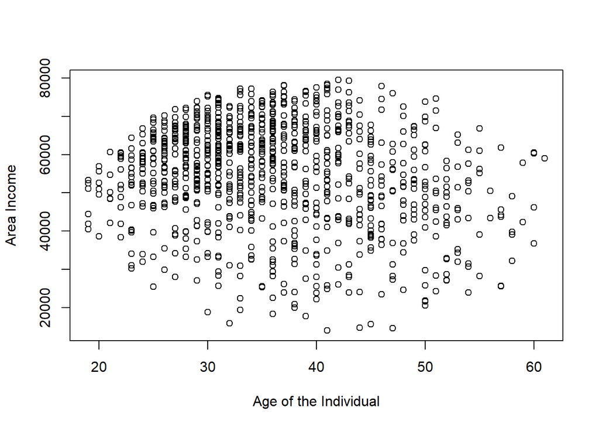

```r
#Using the plot() function to determine the relation
#
plot(Age, income, xlab="Age of the Individual", ylab="Area Income")
```

## age and clicked on advert variable scatter plot

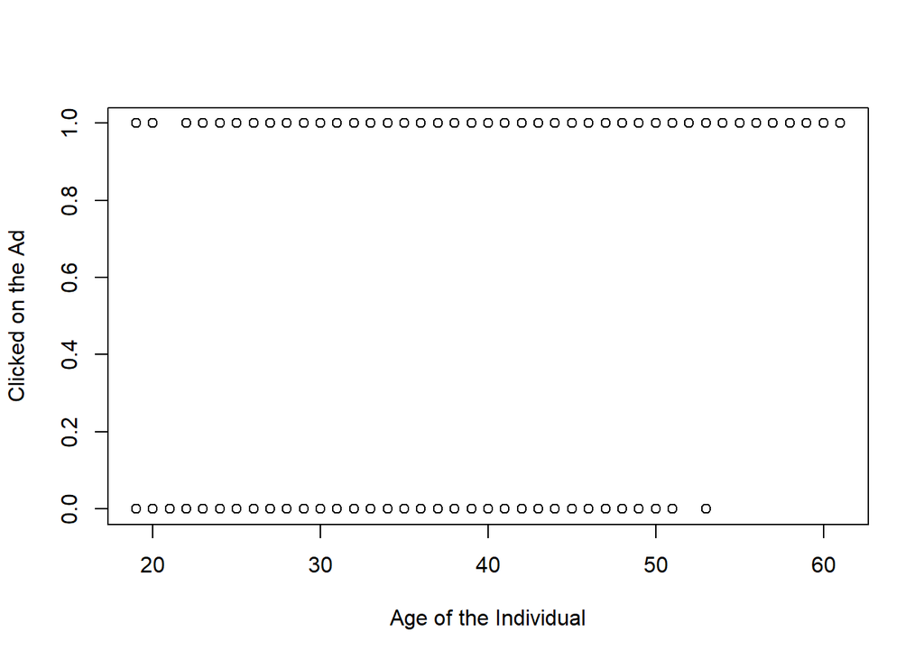

```r
#Using the plot() function to determine the relation
#
plot(Age, Clicked, xlab="Age of the Individual", ylab="Clicked on the Ad")
```

## gender and area income variable scatter plot

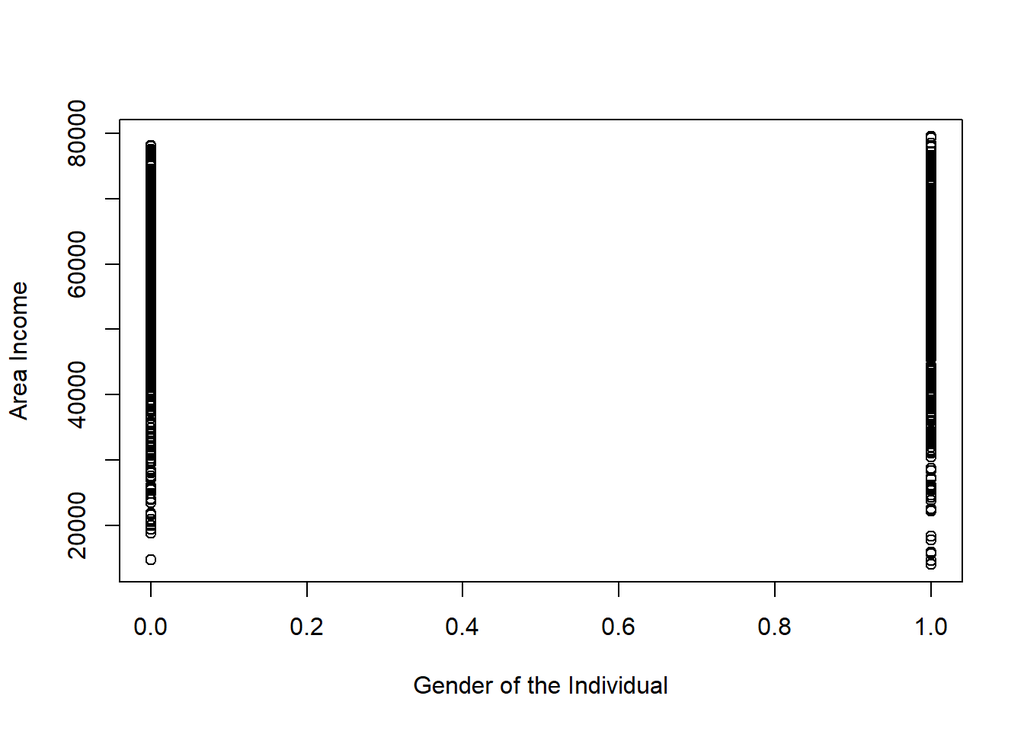

```r
#Using the plot() function to determine the relation
#
plot(Gender, income, xlab="Gender of the Individual", ylab="Area Income")
```

## gender and daily internet usage variable scatter plot

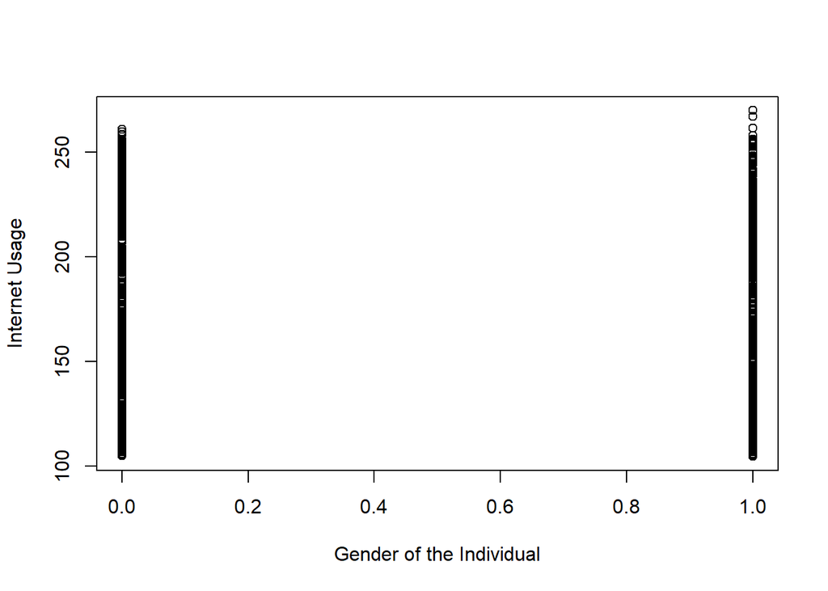

```r
#Using the plot() function to determine the relation
#
plot(Gender, DIU, xlab="Gender of the Individual", ylab="Internet Usage")
```

## gender and daily time spent on site variable scatter plot

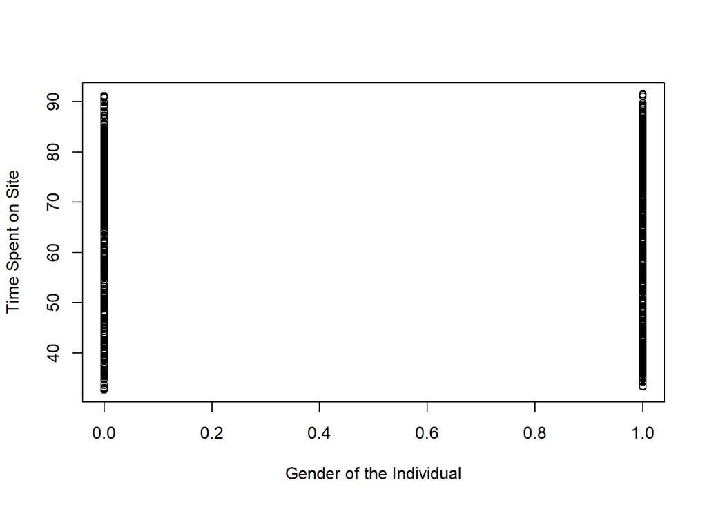

```r
#Using the plot() function to determine the relation
#
plot(Gender, DTSS, xlab="Gender of the Individual", ylab="Time Spent on Site")
```

## income and daily internet usage variable scatter plot

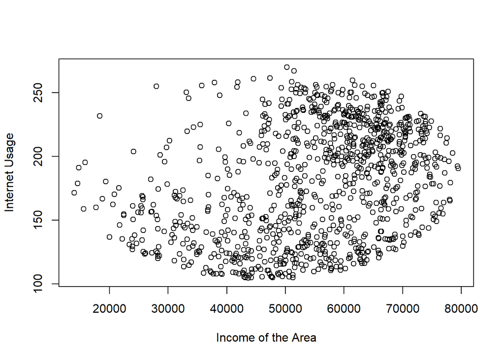

```r
#Using the plot() function to determine the relation
#
plot(income, DIU, xlab="Income of the Area", ylab="Internet Usage")
```

## income and daily time spent on site variable scatter plot

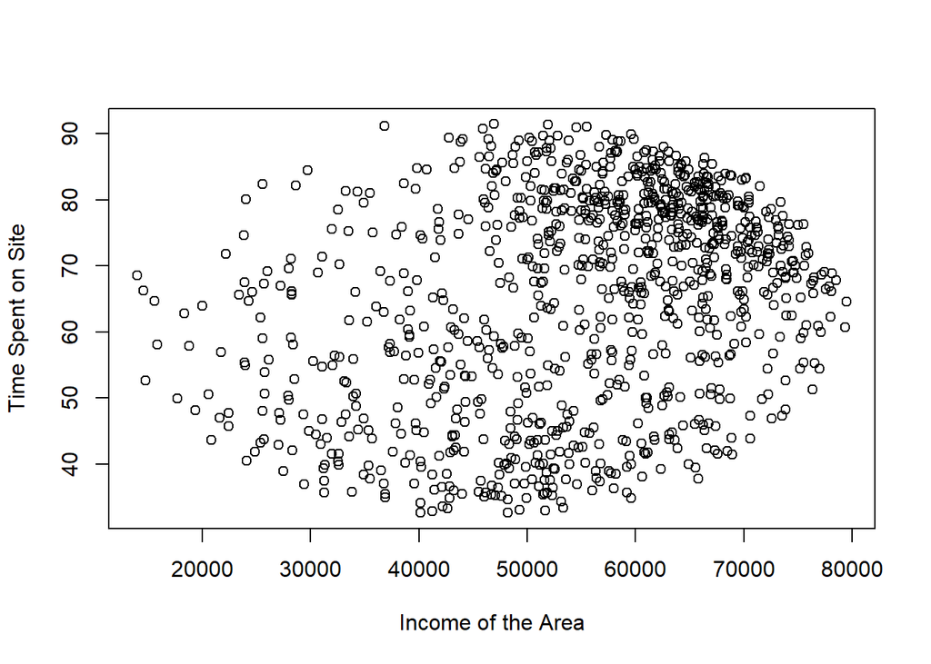

```r
#Using the plot() function to determine the relation
#
plot(income, DTSS, xlab="Income of the Area", ylab="Time Spent on Site")
```